# IE 48B — Homework 3

# 2 Part 2 — Baseline Models (15 pts)

## 2.1 Train/Test Split (3 pts)

Split the data chronologically:

- **Training set:** All data before January 1, 2026
- **Test set:** January 1 – March 31, 2026

```python
train = df[df["datetime"] < "2026-01-01"].copy()
test  = df[df["datetime"] >= "2026-01-01"].copy()

print(f"Training set: {len(train)} observations "
      f"({train['datetime'].min().date()} to {train['datetime'].max().date()})")
print(f"Test set:     {len(test)} observations "
      f"({test['datetime'].min().date()} to {test['datetime'].max().date()})")
```

```
Training set: 35064 observations (2022-01-01 to 2025-12-31)
Test set:     2160 observations (2026-01-01 to 2026-03-31)
```

```python
print(f"| Set | Number of hourly observations |")
print(f"|:---:|:---:|")
print(f"| Training | {len(train)} |")
print(f"| Test | {len(test)} |")
```

```
| Set | Number of hourly observations |
|:---:|:---:|
| Training | 35064 |
| Test | 2160 |
```

## 2.2 Naive and Linear Baselines (12 pts)

Fit at least two baseline models that do **not** use smooth terms. Report the test RMSE for each baseline. Explain what each baseline captures and what it misses. What motivates moving to a GAM? (3–4 sentences.)

```python
def rmse(y_true, y_pred):
    return np.sqrt(mean_squared_error(y_true, y_pred))

# ── Baseline 1: Monthly-Hourly Climatology ──
# Average generation for each (month, hour) combination in training data
clim = train.groupby(["month", "hour"])["solar_gen_mw"].mean()
pred_clim = test.apply(lambda r: clim.get((r["month"], r["hour"]), 0), axis=1)
rmse_clim = rmse(test["solar_gen_mw"], pred_clim)
print(f"Baseline 1 (Monthly-Hourly Climatology) RMSE: {rmse_clim:.1f} MW")

# ── Baseline 2: Linear Regression ──
# Features: hour dummies, month dummies, year_decimal (trend)
from sklearn.preprocessing import OneHotEncoder

cat_features_train = train[["hour", "month"]].values
cat_features_test  = test[["hour", "month"]].values

enc = OneHotEncoder(sparse_output=False, drop="first")
X_cat_train = enc.fit_transform(cat_features_train)
X_cat_test  = enc.transform(cat_features_test)

X_lr_train = np.column_stack([X_cat_train, train["year_decimal"].values])
X_lr_test  = np.column_stack([X_cat_test,  test["year_decimal"].values])

lr = LinearRegression()
lr.fit(X_lr_train, train["solar_gen_mw"].values)
pred_lr = lr.predict(X_lr_test)
pred_lr = np.maximum(pred_lr, 0)  # Generation >= 0

rmse_lr = rmse(test["solar_gen_mw"], pred_lr)
print(f"Baseline 2 (Linear Regression) RMSE: {rmse_lr:.1f} MW")
```

```
Baseline 1 (Monthly-Hourly Climatology) RMSE: 2671.0 MW
Baseline 2 (Linear Regression) RMSE: 2333.7 MW
```

```python
print(f"| Model | Test RMSE (MW) |")
print(f"|:------|:---------:|")
print(f"| Monthly-Hourly Climatology | {rmse_clim:.1f} |")
print(f"| Linear Regression | {rmse_lr:.1f} |")
```

```
| Model | Test RMSE (MW) |
|:------|:---------:|
| Monthly-Hourly Climatology | 2671.0 |
| Linear Regression | 2333.7 |
```

> The **Monthly-Hourly Climatology** baseline captures the average seasonal and diurnal pattern but ignores the year-over-year capacity growth trend, resulting in systematic under-prediction for the 2026 test period. The **Linear Regression** model adds a linear trend via `year_decimal`, which partially corrects this, but it treats the hour and month effects as piecewise-constant (dummy variables) and cannot capture the smooth, bell-shaped diurnal curve or nonlinear weather effects. Neither baseline can adapt its predictions to real-time weather conditions (e.g., cloud cover), which causes large errors on atypical days. This motivates moving to a **GAM**, which can learn smooth nonlinear shapes for each predictor while remaining interpretable.

# 3 Part 3 — GAM Modeling (30 pts)

## 3.1 Initial GAM (10 pts)

Start with a GAM that uses calendar variables as smooth terms. Report the model specification (which terms, basis types, $k$). Report the test RMSE. Plot the partial dependence plots. Do the estimated shapes align with the patterns from your EDA? (2–3 sentences.)

```python
# Feature matrix for GAM: calendar variables only
feature_cols_cal = ["hour", "day_of_year", "year_decimal"]

X_train_cal = train[feature_cols_cal].values
X_test_cal  = test[feature_cols_cal].values
y_train_arr = train["solar_gen_mw"].values
y_test_arr  = test["solar_gen_mw"].values

# Initial GAM: s(hour, 24 splines) + s(day_of_year, 20 splines) + l(year_decimal)
# year_decimal uses a linear term to allow proper extrapolation into the test period
np.random.seed(SEED)
gam_initial = LinearGAM(
    s(0, n_splines=24, spline_order=3) +   # hour of day
    s(1, n_splines=20, spline_order=3) +   # day of year
    l(2)                                    # year_decimal (linear trend)
)
gam_initial.fit(X_train_cal, y_train_arr)

pred_gam_init = gam_initial.predict(X_test_cal)
pred_gam_init = np.maximum(pred_gam_init, 0)
rmse_gam_init = rmse(y_test_arr, pred_gam_init)
print(f"Initial GAM RMSE: {rmse_gam_init:.1f} MW")
print(f"Pseudo R²: {gam_initial.statistics_['pseudo_r2']['explained_deviance']:.4f}")
```

```
Initial GAM RMSE: 2336.1 MW
Pseudo R²: 0.7870
```

```python
print(f"| Model | Test RMSE (MW) |")
print(f"|:------|:---------:|")
print(f"| Initial GAM | {rmse_gam_init:.1f} |")
```

```
| Model | Test RMSE (MW) |
|:------|:---------:|
| Initial GAM | 2336.1 |
```

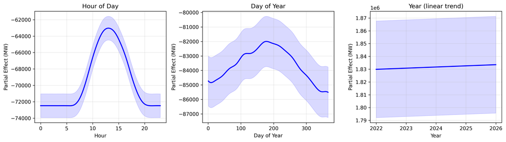

Figure 5: Partial dependence plots — Initial GAM (calendar terms)

```python
fig, axes = plt.subplots(1, 3, figsize=(14, 4))
titles = ["Hour of Day", "Day of Year", "Year (linear trend)"]

for i, (ax, title) in enumerate(zip(axes, titles)):
    XX = gam_initial.generate_X_grid(term=i, n=200)
    pdep, confi = gam_initial.partial_dependence(term=i, X=XX, width=0.95)
    ax.plot(XX[:, i], pdep, color="blue", lw=2)
    ax.fill_between(XX[:, i], confi[:, 0], confi[:, 1], alpha=0.15, color="blue")
    ax.set_title(title)
    ax.set_ylabel("Partial Effect (MW)")
    ax.grid(True, alpha=0.3)

axes[0].set_xlabel("Hour")
axes[1].set_xlabel("Day of Year")
axes[2].set_xlabel("Year")
plt.tight_layout()
plt.show()
```

> **Model specification:** `s(hour, k=24) + s(day_of_year, k=20) + l(year_decimal)`, using cubic B-spline bases for the smooth terms with automatic smoothing parameter selection and a linear term for the trend. A linear trend is used for `year_decimal` because smooth spline terms do not extrapolate well beyond the training data, and the test period (2026) lies at the boundary. The partial dependence plots confirm the EDA patterns: (1) the hour effect shows the expected bell curve peaking around noon, (2) the day-of-year effect captures the seasonal cycle with a peak in June–July and a trough in December–January, and (3) the linear year trend captures the upward growth in installed solar capacity.